# team

Danny Nguyen & COnnor Hergenreter

February 11, 2019

```r
choco <- read.csv("https://xdaiisu.github.io/ds202materials/hwlabs/choco.csv")
summary(choco)
```

```
##      Company             Specific.Bean.Origin      REF
##  Soma    :  47   Madagascar        :  58      Min.   :   5
##  Bonnat  :  27   Peru              :  45      1st Qu.: 600
##  Fresco  :  26   Ecuador           :  43      Median :1099
##  Pralus  :  25   Dominican Republic:  39      Mean   :1065
##  A. Morin:  23   Venezuela         :  21      3rd Qu.:1546
##  Arete   :  22   Chuao             :  20      Max.   :2008
##  (Other) :1682   (Other)           :1626
##   Review.Date     Cocoa.Pct     Company.Location     Rating
##  Min.   :2006   Min.   : 42.0   U.S.A. :787      Min.   :1.000
##  1st Qu.:2010   1st Qu.: 70.0   France :158      1st Qu.:3.000
##  Median :2013   Median : 70.0   Canada :132      Median :3.250
##  Mean   :2012   Mean   : 71.7   U.K.   : 98      Mean   :3.191
##  3rd Qu.:2015   3rd Qu.: 75.0   Italy  : 69      3rd Qu.:3.500
##  Max.   :2017   Max.   :100.0   Ecuador: 55      Max.   :5.000
##                                 (Other):553
##                 Bean.Type            Broad.Bean.Origin
##                      :938   Venezuela         :217
##  Trinitario          :421   Ecuador           :198
##  Criollo             :153   Peru              :171
##  Forastero           : 87   Madagascar        :147
##  Forastero (Nacional): 52   Dominican Republic:145
##  Blend               : 42                     : 74
##  (Other)             :159   (Other)           :900
```

```r
mean(choco$Rating)
```

```
## [1] 3.19101
```

2. How does the number of ratings depend on the year? Draw a bar chart of the number of reports.

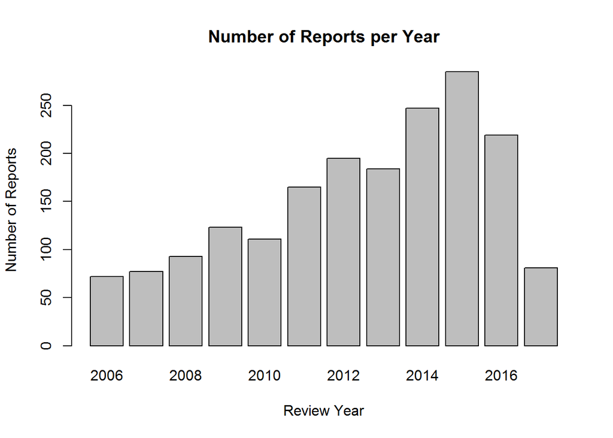

```r
barplot(table(choco$Review.Date), main="Number of Reports per Year", xlab="Review Year", ylab="Number of Reports")
```

3. How do ratings compare across different company locations? Focus on the three locations with the most ratings. (Hint: They are U.S.A., France, and Canada, but find them out using codes.)

Using an aggregate of the ratings and company location it shows that the top three are Canada, France, and U.S.A.. Canada is the best of the big three at 3.3125, France sits at an average of 3.2532, and U.S.A. at 3.1623.

```r
library(ggplot2)
table(choco$Company.Location)
```

```
##
##         Amsterdam         Argentina         Australia           Austria
##                 6                 9                50                27
##           Belgium           Bolivia            Brazil            Canada
##                40                 2                18               132
##             Chile          Colombia        Costa Rica    Czech Republic
##                 2                23                 9                 1
##           Denmark Domincan Republic           Ecuador           Eucador
##                16                 5                55                 1
##              Fiji           Finland            France           Germany
##                 4                 2               158                36
##             Ghana           Grenada         Guatemala          Honduras
##                 1                 3                10                 6
##           Hungary           Iceland             India           Ireland
##                23                 3                 2                 4
##            Israel             Italy             Japan         Lithuania
##                 9                69                17                 6
##        Madagascar        Martinique            Mexico       Netherlands
##                17                 1                 4                 4
##       New Zealand         Niacragua         Nicaragua              Peru
##                17                 1                 5                17
##       Philippines            Poland          Portugal       Puerto Rico
##                 1                 8                 3                 4
##            Russia          Sao Tome          Scotland         Singapore
##                 3                 4                10                 3
##      South Africa       South Korea             Spain         St. Lucia
##                 3                 5                26                 2
##          Suriname            Sweden       Switzerland            U.A.E.
##                 1                 5                38                 4
##              U.K.            U.S.A.         Venezuela           Vietnam
##                98               787                20                11
##             Wales
##                 1
```

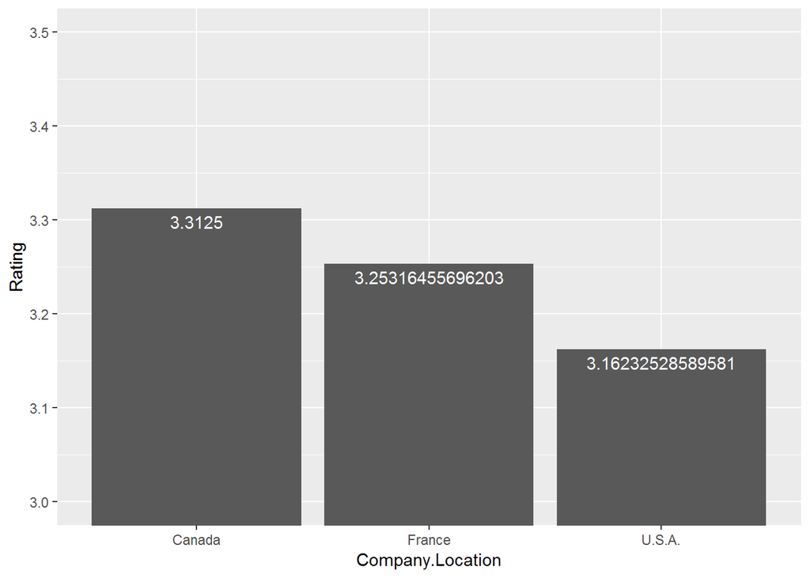

```r
choco2 <- aggregate(Rating ~ Company.Location, choco, mean)
ggplot(subset(choco2, Company.Location %in% c("U.S.A.", "Canada", "France")), aes(x=Company.Location, y=Rating)) + geom_bar(stat="identity") + geom_text(aes(label=Rating), vjust=1.5, color="white") + coord_cartesian(ylim = c(3.0, 3.5))
```

4. Brainstorm and write down an interesting question that can be answer from the dataset. The question should not duplicate the questions above.

Have the average ratings for chocolate bars changed over time?

5. Answer the question from the dataset.

The change is very small but it appears that as time goes on there are less extreme (1 or 5) reviews. Review spread also decreases. The average aslo appears to go up ever so slightly with time as well.

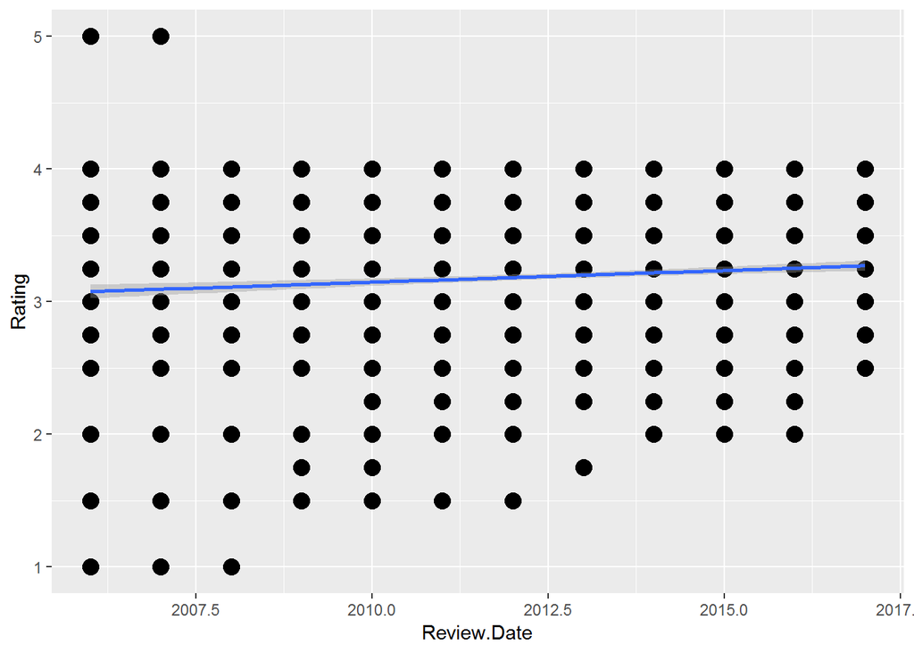

```r
ggplot(choco, aes(x=Review.Date, y=Rating)) + geom_point(size=4) +
geom_smooth(method=lm)
```

https://github.com/dannyn95/ds202_lab2

Our workflow was relatively efficient. It took us roughly an hour to two hours to complete the lab. We divided the work between the both of us. I did questions 1 and 2 while Connor did 3 and 4. Connor also did question 5 since it went along with question 4. Once I completed questions 1 and 2, I pushed them in. Connor then did his part for 3, 4, and 5 pushed it. I made some final adjustments, and this is the final part.